# Assignment_9_10

### Portfolio assignment 9

25 min: Perform a bivariate analysis on the columns with numerical data in the penguins dataset.

- Use corr() on the DataFrame to calculate all the correlations. Use the code example above to show the correlation table with colors.
- Look at the corrrelations. Do they match your expectations?
- Show a scatter plot for
  - The strongest positive correlation
  - The strongest negative correlation
  - The weakest correlation

```python
import pandas as pd
import seaborn as sns
import numpy as np
import matplotlib.pyplot as plt
from scipy.stats import gaussian_kde
```

```python
penguins = sns.load_dataset("penguins")
```

```python
penguins.head()
```

|  | species | island | bill_length_mm | bill_depth_mm | flipper_length_mm | body_mass_g | sex |
| --- | --- | --- | --- | --- | --- | --- | --- |
| 0 | Adelie | Torgersen | 39.1 | 18.7 | 181.0 | 3750.0 | Male |
| 1 | Adelie | Torgersen | 39.5 | 17.4 | 186.0 | 3800.0 | Female |
| 2 | Adelie | Torgersen | 40.3 | 18.0 | 195.0 | 3250.0 | Female |
| 3 | Adelie | Torgersen | NaN | NaN | NaN | NaN | NaN |
| 4 | Adelie | Torgersen | 36.7 | 19.3 | 193.0 | 3450.0 | Female |

[figure not shown]

```python
penguins_color = penguins.corr()
penguins_color.style.background_gradient(cmap='coolwarm', axis=None).set_precision(2)
```

|  | bill_length_mm | bill_depth_mm | flipper_length_mm | body_mass_g |
| --- | --- | --- | --- | --- |
| bill_length_mm | 1.00 | -0.24 | 0.66 | 0.60 |
| bill_depth_mm | -0.24 | 1.00 | -0.58 | -0.47 |
| flipper_length_mm | 0.66 | -0.58 | 1.00 | 0.87 |
| body_mass_g | 0.60 | -0.47 | 0.87 | 1.00 |

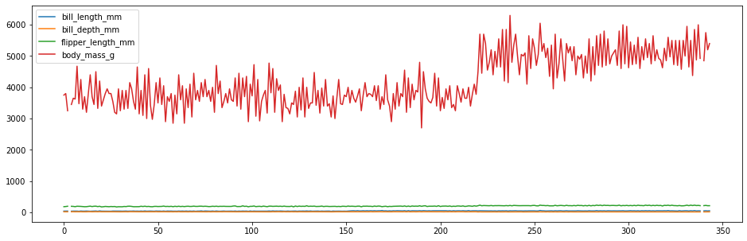

```python
penguins.plot(figsize=(16,5))
```

Overzichtelijker zonder de body_mass_g :

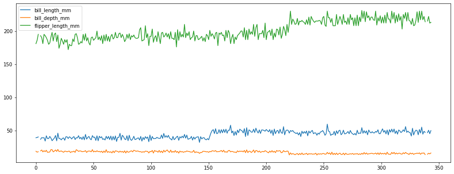

```python
penguins.drop(['body_mass_g'],axis = 1).plot(figsize=(16,6))
```

De correlaties worden weergegeven zoals verwacht, omdat er niet een groot verschil kan zijn in de flipper length, bill depth en bill length. Dit is niet hetzelfde geval voor de body mass. Gewicht is namelijk een meer veranderlijke variabele en die is in de duizenden, integendeel tot de andere variabelen, die maximaal een paar honderd kan zijn. Je ziet hierboven dat de flipper length enigzins een correlatie heeft met de bill length. Als de flipper length omhoog schiet, dan zie je dat ook een beetje bij de bill length.

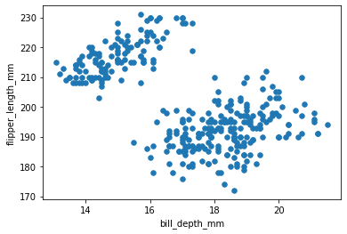

```python
penguins.plot(kind='scatter', x='bill_depth_mm', y='flipper_length_mm', s=30)
```

Strongest negative correlation

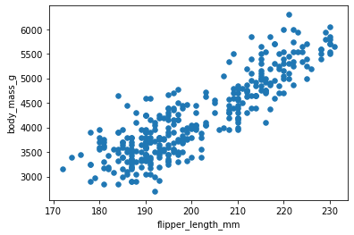

```python
penguins.plot(kind='scatter', x='flipper_length_mm', y='body_mass_g', s=30)
```

Strongest positive correlation

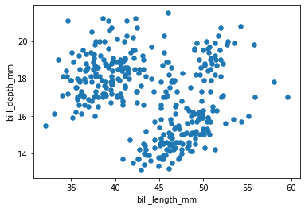

```python
penguins.plot(kind='scatter', x='bill_length_mm', y='bill_depth_mm',s=30)
```

Weakest correlation

### Portfolio assignment 10

15 min: Perform a bivariate analysis (Pearson correlation and scatter plot) on at least 1 combination of 2 columns with numeric data in the dataset that you chose in portfolio assignment 4. Does the correlation and scatter plot match your expectations? Add your answer to your notebook. Commit the Notebook to your portfolio when you're finished.

```python
import pandas as pd

movies = pd.read_csv (r'movies.csv')
```

```python
movies.columns
```

```
Index(['budget', 'genres', 'homepage', 'id', 'keywords', 'original_language',
       'original_title', 'overview', 'popularity', 'production_companies',
       'production_countries', 'release_date', 'revenue', 'runtime',
       'spoken_languages', 'status', 'tagline', 'title', 'vote_average',
       'vote_count'],
      dtype='object')
```

```python
movies.head()
```

|  | budget | genres | homepage | id | keywords | original_language | original_title | overview | popularity | production_companies | production_countries | release_date | revenue | runtime | spoken_languages | status | tagline | title | vote_average | vote_count |
| --- | --- | --- | --- | --- | --- | --- | --- | --- | --- | --- | --- | --- | --- | --- | --- | --- | --- | --- | --- | --- |
| 0 | 237000000 | [{"id": 28, "name": "Action"}, {"id": 12, "nam... | http://www.avatarmovie.com/ | 19995 | [{"id": 1463, "name": "culture clash"}, {"id":... | en | Avatar | In the 22nd century, a paraplegic Marine is di... | 150.437577 | [{"name": "Ingenious Film Partners", "id": 289... | [{"iso_3166_1": "US", "name": "United States o... | 2009-12-10 | 2787965087 | 162.0 | [{"iso_639_1": "en", "name": "English"}, {"iso... | Released | Enter the World of Pandora. | Avatar | 7.2 | 11800 |
| 1 | 300000000 | [{"id": 12, "name": "Adventure"}, {"id": 14, "... | http://disney.go.com/disneypictures/pirates/ | 285 | [{"id": 270, "name": "ocean"}, {"id": 726, "na... | en | Pirates of the Caribbean: At World's End | Captain Barbossa, long believed to be dead, ha... | 139.082615 | [{"name": "Walt Disney Pictures", "id": 2}, {"... | [{"iso_3166_1": "US", "name": "United States o... | 2007-05-19 | 961000000 | 169.0 | [{"iso_639_1": "en", "name": "English"}] | Released | At the end of the world, the adventure begins. | Pirates of the Caribbean: At World's End | 6.9 | 4500 |
| 2 | 245000000 | [{"id": 28, "name": "Action"}, {"id": 12, "nam... | http://www.sonypictures.com/movies/spectre/ | 206647 | [{"id": 470, "name": "spy"}, {"id": 818, "name... | en | Spectre | A cryptic message from Bond’s past sends him o... | 107.376788 | [{"name": "Columbia Pictures", "id": 5}, {"nam... | [{"iso_3166_1": "GB", "name": "United Kingdom"... | 2015-10-26 | 880674609 | 148.0 | [{"iso_639_1": "fr", "name": "Fran\u00e7ais"},... | Released | A Plan No One Escapes | Spectre | 6.3 | 4466 |
| 3 | 250000000 | [{"id": 28, "name": "Action"}, {"id": 80, "nam... | http://www.thedarkknightrises.com/ | 49026 | [{"id": 849, "name": "dc comics"}, {"id": 853,... | en | The Dark Knight Rises | Following the death of District Attorney Harve... | 112.312950 | [{"name": "Legendary Pictures", "id": 923}, {"... | [{"iso_3166_1": "US", "name": "United States o... | 2012-07-16 | 1084939099 | 165.0 | [{"iso_639_1": "en", "name": "English"}] | Released | The Legend Ends | The Dark Knight Rises | 7.6 | 9106 |
| 4 | 260000000 | [{"id": 28, "name": "Action"}, {"id": 12, "nam... | http://movies.disney.com/john-carter | 49529 | [{"id": 818, "name": "based on novel"}, {"id":... | en | John Carter | John Carter is a war-weary, former military ca... | 43.926995 | [{"name": "Walt Disney Pictures", "id": 2}] | [{"iso_3166_1": "US", "name": "United States o... | 2012-03-07 | 284139100 | 132.0 | [{"iso_639_1": "en", "name": "English"}] | Released | Lost in our world, found in another. | John Carter | 6.1 | 2124 |

```python
movies_color = movies.corr()
movies_color.style.background_gradient(cmap='coolwarm', axis=None).set_precision(2)
```

|  | budget | id | popularity | revenue | runtime | vote_average | vote_count |
| --- | --- | --- | --- | --- | --- | --- | --- |
| budget | 1.00 | -0.09 | 0.51 | 0.73 | 0.27 | 0.09 | 0.59 |
| id | -0.09 | 1.00 | 0.03 | -0.05 | -0.15 | -0.27 | -0.00 |
| popularity | 0.51 | 0.03 | 1.00 | 0.64 | 0.23 | 0.27 | 0.78 |
| revenue | 0.73 | -0.05 | 0.64 | 1.00 | 0.25 | 0.20 | 0.78 |
| runtime | 0.27 | -0.15 | 0.23 | 0.25 | 1.00 | 0.38 | 0.27 |
| vote_average | 0.09 | -0.27 | 0.27 | 0.20 | 0.38 | 1.00 | 0.31 |
| vote_count | 0.59 | -0.00 | 0.78 | 0.78 | 0.27 | 0.31 | 1.00 |

Alle correlaties tussen de numerieke kolommen van de movies dataset.

Correlatie zien tussen het aantal votes en revenue.

```python
movies[['vote_count','revenue']].corr()
```

|  | vote_count | revenue |
| --- | --- | --- |
| vote_count | 1.000000 | 0.781487 |
| revenue | 0.781487 | 1.000000 |

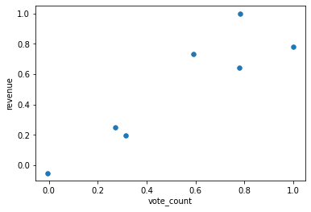

```python
movies_color.plot(kind='scatter', x='vote_count', y='revenue', s=30)
```

Positive correlation: 0.8

Een hoog budget betekent meestal dat het een bekende film is. Bekende films worden vaker beoordeeld.

Correlatie zien tussen het budget en de opbrengst van de films.

```python
movies[['budget','revenue']].corr()
```

|  | budget | revenue |
| --- | --- | --- |
| budget | 1.000000 | 0.730823 |
| revenue | 0.730823 | 1.000000 |

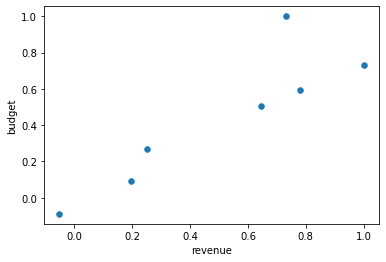

```python
movies_color.plot(kind='scatter', x='revenue', y='budget', s=30)
```

Positive correlation: 0.7

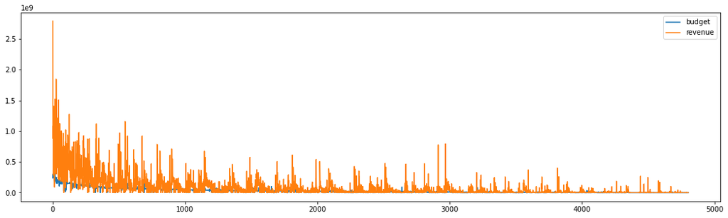

```python
# Excluding a couple of columns because their values are too high to show in the same plot
movies.drop(['id', 'vote_count', 'runtime', 'popularity', 'vote_average'], axis=1).plot(figsize=(18,5))
```

Het resultaat is zoals verwacht. Meestal hoe hoger het budget, hoe hoger de revenue. Er zijn enkele uitschieters waarbij het budget hoger is dan de revenue (verlies).

Correlatie zien tussen de runtime en populariteit van de films.

```python
movies[['popularity','runtime']].corr()
```

|  | popularity | runtime |
| --- | --- | --- |
| popularity | 1.000000 | 0.225502 |
| runtime | 0.225502 | 1.000000 |

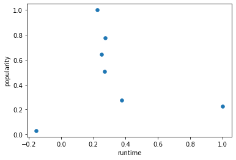

```python
movies_color.plot(kind='scatter', x='runtime', y='popularity', s=30)
```

Positive correlation: 0.2

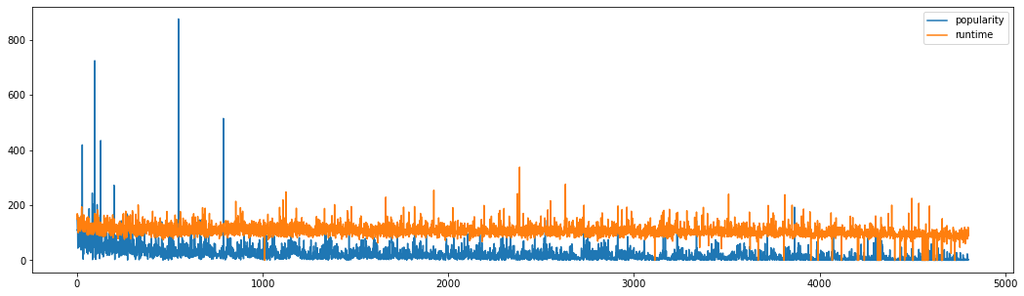

```python
# Excluding a couple of columns because their values are too high to show in the same plot
movies.drop(['id', 'vote_count', 'revenue', 'budget', 'vote_average'], axis=1).plot(figsize=(18,5))
```

Hier zie je dat er een hele kleine samenhang ligt tussen de populariteit van een film en de afspeelduur. Films die meer an 3 uur lang zijn, zijn meestal niet al te populair. Evenals de 'short films'.